# Séance 9 - *correction*

```python
import pandas

url = "https://archive.ics.uci.edu/ml/machine-learning-databases/ozone/onehr.data"
data = pandas.read_csv(url, header = None, na_values = "?")
data
```

|  | 0 | 1 | 2 | 3 | 4 | 5 | 6 | 7 | 8 | 9 | ... | 64 | 65 | 66 | 67 | 68 | 69 | 70 | 71 | 72 | 73 |
| --- | --- | --- | --- | --- | --- | --- | --- | --- | --- | --- | --- | --- | --- | --- | --- | --- | --- | --- | --- | --- | --- |
| 0 | 1/1/1998 | 0.8 | 1.8 | 2.4 | 2.1 | 2.0 | 2.1 | 1.5 | 1.7 | 1.9 | ... | 0.15 | 10.67 | -1.56 | 5795.0 | -12.10 | 17.90 | 10330.0 | -55.0 | 0.00 | 0.0 |
| 1 | 1/2/1998 | 2.8 | 3.2 | 3.3 | 2.7 | 3.3 | 3.2 | 2.9 | 2.8 | 3.1 | ... | 0.48 | 8.39 | 3.84 | 5805.0 | 14.05 | 29.00 | 10275.0 | -55.0 | 0.00 | 0.0 |
| 2 | 1/3/1998 | 2.9 | 2.8 | 2.6 | 2.1 | 2.2 | 2.5 | 2.5 | 2.7 | 2.2 | ... | 0.60 | 6.94 | 9.80 | 5790.0 | 17.90 | 41.30 | 10235.0 | -40.0 | 0.00 | 0.0 |
| 3 | 1/4/1998 | 4.7 | 3.8 | 3.7 | 3.8 | 2.9 | 3.1 | 2.8 | 2.5 | 2.4 | ... | 0.49 | 8.73 | 10.54 | 5775.0 | 31.15 | 51.70 | 10195.0 | -40.0 | 2.08 | 0.0 |
| 4 | 1/5/1998 | 2.6 | 2.1 | 1.6 | 1.4 | 0.9 | 1.5 | 1.2 | 1.4 | 1.3 | ... | NaN | NaN | NaN | NaN | NaN | NaN | NaN | NaN | 0.58 | 0.0 |
| ... | ... | ... | ... | ... | ... | ... | ... | ... | ... | ... | ... | ... | ... | ... | ... | ... | ... | ... | ... | ... | ... |
| 2531 | 12/27/2004 | 0.3 | 0.4 | 0.5 | 0.5 | 0.2 | 0.3 | 0.4 | 0.4 | 1.3 | ... | 0.07 | 7.93 | -4.41 | 5800.0 | -25.60 | 21.80 | 10295.0 | 65.0 | 0.00 | 0.0 |
| 2532 | 12/28/2004 | 1.0 | 1.4 | 1.1 | 1.7 | 1.5 | 1.7 | 1.8 | 1.5 | 2.1 | ... | 0.04 | 5.95 | -1.14 | 5845.0 | -19.40 | 19.10 | 10310.0 | 15.0 | 0.00 | 0.0 |
| 2533 | 12/29/2004 | 0.8 | 0.8 | 1.2 | 0.9 | 0.4 | 0.6 | 0.8 | 1.1 | 1.5 | ... | 0.06 | 7.80 | -0.64 | 5845.0 | -9.60 | 35.20 | 10275.0 | -35.0 | 0.00 | 0.0 |
| 2534 | 12/30/2004 | 1.3 | 0.9 | 1.5 | 1.2 | 1.6 | 1.8 | 1.1 | 1.0 | 1.9 | ... | 0.25 | 7.72 | -0.89 | 5845.0 | -19.60 | 34.20 | 10245.0 | -30.0 | 0.05 | 0.0 |
| 2535 | 12/31/2004 | 1.5 | 1.3 | 1.8 | 1.4 | 1.2 | 1.7 | 1.6 | 1.4 | 1.6 | ... | 0.54 | 13.07 | 9.15 | 5820.0 | 1.95 | 39.35 | 10220.0 | -25.0 | 0.00 | 0.0 |

2536 rows × 74 columns

```python
import requests

response = requests.get("https://archive.ics.uci.edu/ml/machine-learning-databases/ozone/onehr.names")
print(response.text)
```

```
1. Title: Ozone Level Detection


2. Source:

Kun Zhang
zhang.kun05 '@' gmail.com
Department of Computer Science,
Xavier University of Lousiana

Wei Fan
wei.fan '@' gmail.com
IBM T.J.Watson Research

XiaoJing Yuan
xyuan '@' uh.edu
Engineering Technology Department,
College of Technology, University of Houston


3. Past Usage:

Forecasting skewed biased stochastic ozone days: analyses, solutions and beyond, Knowledge and Information Systems, Vol. 14, No. 3, 2008.
Discusses details about the dataset, its use as well as various experiments (both cross-validation and streaming) using many state-of-the-art methods.

A shorter version of the paper (does not contain some detailed experiments as the journal paper above) is in:
Forecasting Skewed Biased Stochastic Ozone Days: Analyses and Solutions. ICDM 2006: 753-764


4. Relevant Information:

The following are specifications for several most important attributes
that are highly valued by Texas Commission on Environmental Quality (TCEQ).
More details can be found in the two relevant papers.

-- O 3 - Local ozone peak prediction
-- Upwind - Upwind ozone background level
-- EmFactor - Precursor emissions related factor
-- Tmax - Maximum temperature in degrees F
-- Tb - Base temperature where net ozone production begins (50 F)
```

[output cut: 73 more lines]

```
T70:     continuous.
RH70:     continuous.
U70:     continuous.
V70:     continuous.
HT70:     continuous.
T50:     continuous.
RH50:     continuous.
U50:     continuous.
V50:     continuous.
HT50:     continuous.
KI:     continuous.
TT:     continuous.
SLP:     continuous.
SLP_:     continuous.
Precp:    continuous.
```

## 1- Importation des données

```python
data.columns = [t.split(":")[0] for t in response.text.split("\n")[55:]][:-1] + ["ozone"]
data
```

|  | Date | WSR0 | WSR1 | WSR2 | WSR3 | WSR4 | WSR5 | WSR6 | WSR7 | WSR8 | ... | RH50 | U50 | V50 | HT50 | KI | TT | SLP | SLP_ | Precp | ozone |
| --- | --- | --- | --- | --- | --- | --- | --- | --- | --- | --- | --- | --- | --- | --- | --- | --- | --- | --- | --- | --- | --- |
| 0 | 1/1/1998 | 0.8 | 1.8 | 2.4 | 2.1 | 2.0 | 2.1 | 1.5 | 1.7 | 1.9 | ... | 0.15 | 10.67 | -1.56 | 5795.0 | -12.10 | 17.90 | 10330.0 | -55.0 | 0.00 | 0.0 |
| 1 | 1/2/1998 | 2.8 | 3.2 | 3.3 | 2.7 | 3.3 | 3.2 | 2.9 | 2.8 | 3.1 | ... | 0.48 | 8.39 | 3.84 | 5805.0 | 14.05 | 29.00 | 10275.0 | -55.0 | 0.00 | 0.0 |
| 2 | 1/3/1998 | 2.9 | 2.8 | 2.6 | 2.1 | 2.2 | 2.5 | 2.5 | 2.7 | 2.2 | ... | 0.60 | 6.94 | 9.80 | 5790.0 | 17.90 | 41.30 | 10235.0 | -40.0 | 0.00 | 0.0 |
| 3 | 1/4/1998 | 4.7 | 3.8 | 3.7 | 3.8 | 2.9 | 3.1 | 2.8 | 2.5 | 2.4 | ... | 0.49 | 8.73 | 10.54 | 5775.0 | 31.15 | 51.70 | 10195.0 | -40.0 | 2.08 | 0.0 |
| 4 | 1/5/1998 | 2.6 | 2.1 | 1.6 | 1.4 | 0.9 | 1.5 | 1.2 | 1.4 | 1.3 | ... | NaN | NaN | NaN | NaN | NaN | NaN | NaN | NaN | 0.58 | 0.0 |
| ... | ... | ... | ... | ... | ... | ... | ... | ... | ... | ... | ... | ... | ... | ... | ... | ... | ... | ... | ... | ... | ... |
| 2531 | 12/27/2004 | 0.3 | 0.4 | 0.5 | 0.5 | 0.2 | 0.3 | 0.4 | 0.4 | 1.3 | ... | 0.07 | 7.93 | -4.41 | 5800.0 | -25.60 | 21.80 | 10295.0 | 65.0 | 0.00 | 0.0 |
| 2532 | 12/28/2004 | 1.0 | 1.4 | 1.1 | 1.7 | 1.5 | 1.7 | 1.8 | 1.5 | 2.1 | ... | 0.04 | 5.95 | -1.14 | 5845.0 | -19.40 | 19.10 | 10310.0 | 15.0 | 0.00 | 0.0 |
| 2533 | 12/29/2004 | 0.8 | 0.8 | 1.2 | 0.9 | 0.4 | 0.6 | 0.8 | 1.1 | 1.5 | ... | 0.06 | 7.80 | -0.64 | 5845.0 | -9.60 | 35.20 | 10275.0 | -35.0 | 0.00 | 0.0 |
| 2534 | 12/30/2004 | 1.3 | 0.9 | 1.5 | 1.2 | 1.6 | 1.8 | 1.1 | 1.0 | 1.9 | ... | 0.25 | 7.72 | -0.89 | 5845.0 | -19.60 | 34.20 | 10245.0 | -30.0 | 0.05 | 0.0 |
| 2535 | 12/31/2004 | 1.5 | 1.3 | 1.8 | 1.4 | 1.2 | 1.7 | 1.6 | 1.4 | 1.6 | ... | 0.54 | 13.07 | 9.15 | 5820.0 | 1.95 | 39.35 | 10220.0 | -25.0 | 0.00 | 0.0 |

2536 rows × 74 columns

## 2- Suppression des données manquantes

```python
data.count()
```

```
Date     2536
WSR0     2237
WSR1     2244
WSR2     2242
WSR3     2244
         ...
TT       2411
SLP      2441
SLP_     2377
Precp    2534
ozone    2536
Length: 74, dtype: int64
```

```python
data = data.dropna()
data.count()
```

```
Date     1848
WSR0     1848
WSR1     1848
WSR2     1848
WSR3     1848
         ...
TT       1848
SLP      1848
SLP_     1848
Precp    1848
ozone    1848
Length: 74, dtype: int64
```

## Chargement des différents modules utiles

```python
import numpy
import matplotlib.pyplot as plt
import seaborn
seaborn.set_style("white")

from sklearn.preprocessing import scale
from sklearn.decomposition import PCA
from sklearn.cluster import AgglomerativeClustering
from sklearn.cluster import KMeans
from sklearn.metrics import roc_curve, auc
from sklearn.linear_model import LogisticRegression
from sklearn.neighbors import KNeighborsClassifier
from sklearn.tree import DecisionTreeClassifier, plot_tree
from sklearn.neural_network import MLPClassifier
```

## Création de deux objets `X` et `y` ppour simplification du code par la suite

```python
X = data.drop(["Date", "ozone"], axis = 1)
X.head()
```

|  | WSR0 | WSR1 | WSR2 | WSR3 | WSR4 | WSR5 | WSR6 | WSR7 | WSR8 | WSR9 | ... | T50 | RH50 | U50 | V50 | HT50 | KI | TT | SLP | SLP_ | Precp |
| --- | --- | --- | --- | --- | --- | --- | --- | --- | --- | --- | --- | --- | --- | --- | --- | --- | --- | --- | --- | --- | --- |
| 0 | 0.8 | 1.8 | 2.4 | 2.1 | 2.0 | 2.1 | 1.5 | 1.7 | 1.9 | 2.3 | ... | -15.5 | 0.15 | 10.67 | -1.56 | 5795.0 | -12.10 | 17.90 | 10330.0 | -55.0 | 0.00 |
| 1 | 2.8 | 3.2 | 3.3 | 2.7 | 3.3 | 3.2 | 2.9 | 2.8 | 3.1 | 3.4 | ... | -14.5 | 0.48 | 8.39 | 3.84 | 5805.0 | 14.05 | 29.00 | 10275.0 | -55.0 | 0.00 |
| 2 | 2.9 | 2.8 | 2.6 | 2.1 | 2.2 | 2.5 | 2.5 | 2.7 | 2.2 | 2.5 | ... | -15.9 | 0.60 | 6.94 | 9.80 | 5790.0 | 17.90 | 41.30 | 10235.0 | -40.0 | 0.00 |
| 3 | 4.7 | 3.8 | 3.7 | 3.8 | 2.9 | 3.1 | 2.8 | 2.5 | 2.4 | 3.1 | ... | -16.8 | 0.49 | 8.73 | 10.54 | 5775.0 | 31.15 | 51.70 | 10195.0 | -40.0 | 2.08 |
| 6 | 3.7 | 3.2 | 3.8 | 5.1 | 6.0 | 7.0 | 6.3 | 6.4 | 6.3 | 5.4 | ... | -11.8 | 0.84 | 6.86 | 25.60 | 5695.0 | 26.75 | 48.45 | 10040.0 | -80.0 | 0.18 |

5 rows × 72 columns

```python
y = data["ozone"]
y
```

```
0       0.0
1       0.0
2       0.0
3       0.0
6       0.0
       ...
2531    0.0
2532    0.0
2533    0.0
2534    0.0
2535    0.0
Name: ozone, Length: 1848, dtype: float64
```

## 3- ACP

```python
pca = PCA().fit(scale(X))
```

```python
eig = pandas.DataFrame(
    {
        "Dimension" : ["Dim" + str(x + 1) for x in range(X.shape[1])],
        "Valeur propre" : pca.explained_variance_,
        "% variance expliquée" : numpy.round(pca.explained_variance_ratio_ * 100),
        "% cum. var. expliquée" : numpy.round(numpy.cumsum(pca.explained_variance_ratio_) * 100)
    },
    columns = ["Dimension", "Valeur propre", "% variance expliquée", "% cum. var. expliquée"]
)
eig
```

|  | Dimension | Valeur propre | % variance expliquée | % cum. var. expliquée |
| --- | --- | --- | --- | --- |
| 0 | Dim1 | 30.198708 | 42.0 | 42.0 |
| 1 | Dim2 | 15.213201 | 21.0 | 63.0 |
| 2 | Dim3 | 5.474564 | 8.0 | 71.0 |
| 3 | Dim4 | 3.170343 | 4.0 | 75.0 |
| 4 | Dim5 | 2.620298 | 4.0 | 79.0 |
| ... | ... | ... | ... | ... |
| 67 | Dim68 | 0.000757 | 0.0 | 100.0 |
| 68 | Dim69 | 0.000606 | 0.0 | 100.0 |
| 69 | Dim70 | 0.000499 | 0.0 | 100.0 |
| 70 | Dim71 | 0.000396 | 0.0 | 100.0 |
| 71 | Dim72 | 0.000018 | 0.0 | 100.0 |

72 rows × 4 columns

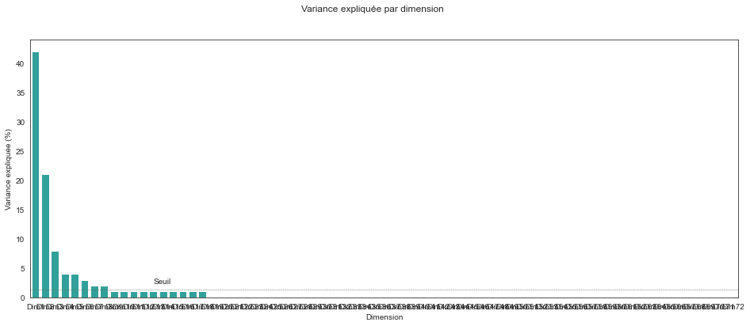

```python
plt.figure(figsize=(16, 6))
g_eig = seaborn.barplot(x = "Dimension",
                        y = "% variance expliquée",
                        color = "lightseagreen",
                        data = eig)
plt.text(12, 100/X.shape[1] + 1, "Seuil")
plt.axhline(y = 100/X.shape[1], linewidth = .5, color = "dimgray", linestyle = "--")
g_eig.set(ylabel = "Variance expliquée (%)")
g_eig.figure.suptitle("Variance expliquée par dimension")

plt.show()
```

Dans le tableau et le graphique ci-dessous, nous remarquons que les 2 premières composantes permettent d'expliquer à elles-seules **63% de l'information**.

Par contre, dans le plan factoriel ci-dessous, nous ne remarquons pas de structure en classe.

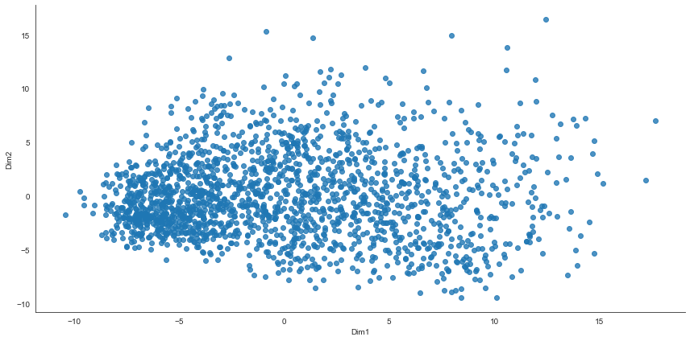

```python
X_pca_row = pandas.DataFrame(pca.transform(scale(X)),
                             columns = ["Dim" + str(i+1) for i in range(X.shape[1])])
g_pca = seaborn.lmplot(data = X_pca_row, x = "Dim1", y = "Dim2", height = 6, aspect = 2, fit_reg = False)
plt.show()
```

Si nous regardons le cercle des corrélations, nous remarquons que certaines variables sont très proches entre elles. Cela s'explique par le fait qu'il y ait beaucoup de variables, avec certains très corrélées entre elles (cf graphique ci-après - en particulier les variables `Tx`, mais aussi les `WSRx`). Dans un travail complet, nous devrions sélectionner uniquement certaines variables (par exemple `WSR_PK` et `T_PK`).

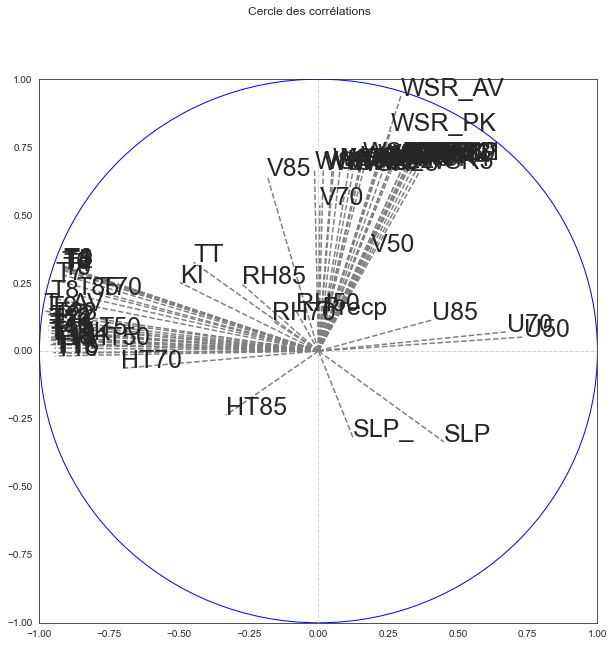

```python
coordvar_df = pandas.DataFrame(pca.components_.T * numpy.sqrt(pca.explained_variance_),
                               columns=['PC'+str(i+1) for i in range(X_pca_row.shape[1])],
                               index=X.columns)

fig, axes = plt.subplots(figsize = (10, 10))
fig.suptitle("Cercle des corrélations")
axes.set_xlim(-1, 1)
axes.set_ylim(-1, 1)
axes.axvline(x = 0, color = 'lightgray', linestyle = '--', linewidth = 1)
axes.axhline(y = 0, color = 'lightgray', linestyle = '--', linewidth = 1)
for j in range(X.shape[1]):
    axes.text(coordvar_df["PC1"].iloc[j],coordvar_df["PC2"].iloc[j], coordvar_df.index[j], size = 25)
    axes.plot([0,coordvar_df["PC1"].iloc[j]], [0,coordvar_df["PC2"].iloc[j]], color = "gray", linestyle = 'dashed')
plt.gca().add_artist(plt.Circle((0,0),1,color='blue',fill=False))

plt.show()
```

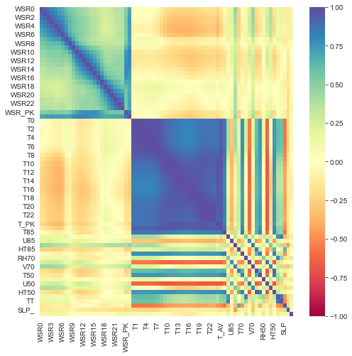

```python
plt.figure(figsize=(8, 8))
seaborn.heatmap(X.corr(), vmin = -1, vmax = 1, cmap = "Spectral")
plt.show()
```

## 4- Variable cible sur ACP

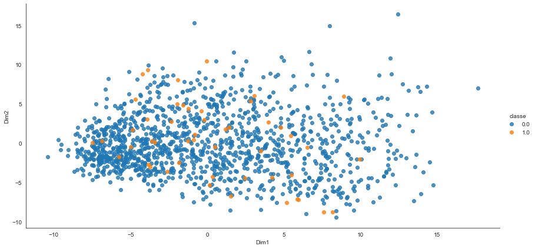

```python
g_pca = seaborn.lmplot(
    data = X_pca_row.assign(classe = y),
    x = "Dim1", y = "Dim2", hue = "classe", fit_reg = False,
    height = 6, aspect = 2)
plt.show()
```

## 5- Partition

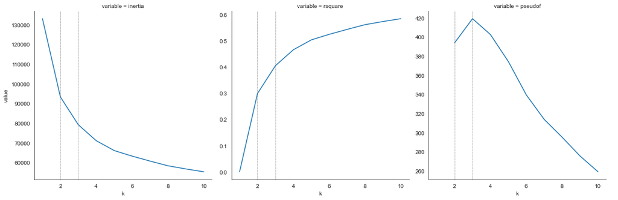

```python
inertia = []
for k in range(1, 11):
    kmeans = KMeans(n_clusters = k, init = "random", n_init = 20).fit(scale(X))
    inertia = inertia + [kmeans.inertia_]

rsquare = [(inertia[0] - i) / inertia[0] for i in inertia]
criteres = pandas.DataFrame({
    "k": range(1, 11),
    "inertia": inertia,
    "rsquare": rsquare,
    "pseudof": [(rsquare[k-1] / k) / ((1 - rsquare[k-1]) / (X.shape[0] - k)) if k > 1 else None for k in range(1, 11)]
})

g = seaborn.FacetGrid(data = criteres.melt(id_vars = "k"), col = "variable", sharey = False,
                      height = 5, aspect = 1)
g.map_dataframe(seaborn.lineplot, x = "k", y = "value")
g.map(plt.axvline, x = 2, linewidth = .5, color = "dimgray", linestyle = "--")
g.map(plt.axvline, x = 3, linewidth = .5, color = "dimgray", linestyle = "--")
g.add_legend()
plt.show()
```

A l'aide de $k$-means, et des graphiques ci-desssus, on peut choisir soit 2 classes (en se basant sur l'évolution de l'inertie et du $R^2$) ou 3 classes (en se basant sur le $PseudoF$). Nous allons choisir ici **3 classes**.

```python
kmeans = KMeans(n_clusters = 3, init = "random", n_init = 20).fit(scale(X))
```

Les classes sont clairement séparées sur le plan factoriel. La plupart des jours avec dépassement d'ozone sont principalement dans une même classe.

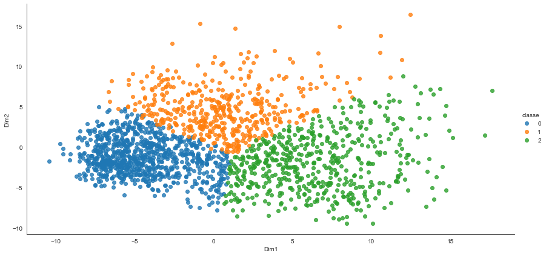

```python
g_pca = seaborn.lmplot(
    data = X_pca_row.assign(classe = kmeans.labels_),
    x = "Dim1", y = "Dim2", hue = "classe", fit_reg = False,
    height = 6, aspect = 2)
plt.show()
```

```python
pandas.crosstab(kmeans.labels_, y)
```

| ozone row_0 | 0.0 | 1.0 |
| --- | --- | --- |
| 0 | 805 | 53 |
| 1 | 448 | 0 |
| 2 | 538 | 4 |

## 6- Modélisation avec les 4 algos

### Régression logistique

```python
m_log = LogisticRegression(max_iter = 10000).fit(X, y)
```

```python
pandas.crosstab(m_log.predict(X), y)
```

| ozone row_0 | 0.0 | 1.0 |
| --- | --- | --- |
| 0.0 | 1784 | 41 |
| 1.0 | 7 | 16 |

```python
m_log.score(X, y)
```

```
0.974025974025974
```

### $k$-plus proches voisins

```python
r2 = []

k_val = (1, 2, 3, 4, 5, 10, 15, 20)
for k in k_val:
    m_knn = KNeighborsClassifier(n_neighbors = k).fit(scale(X), y)
    r2 = r2 + [m_knn.score(scale(X), y)]

df = pandas.DataFrame({
    "variable": k_val,
    "r2": r2
})
df
```

|  | variable | r2 |
| --- | --- | --- |
| 0 | 1 | 1.000000 |
| 1 | 2 | 0.975649 |
| 2 | 3 | 0.977814 |
| 3 | 4 | 0.970779 |
| 4 | 5 | 0.972403 |
| 5 | 10 | 0.971320 |
| 6 | 15 | 0.969697 |
| 7 | 20 | 0.969156 |

```python
m_knn = KNeighborsClassifier(n_neighbors = 3).fit(scale(X), y)
```

```python
pandas.crosstab(m_knn.predict(scale(X)), y)
```

| ozone row_0 | 0.0 | 1.0 |
| --- | --- | --- |
| 0.0 | 1786 | 36 |
| 1.0 | 5 | 21 |

```python
m_knn.score(scale(X), y)
```

```
0.9778138528138528
```

### CART

```python
m_tree = DecisionTreeClassifier().fit(X, y)
```

```python
pandas.crosstab(m_tree.predict(X), y)
```

| ozone row_0 | 0.0 | 1.0 |
| --- | --- | --- |
| 0.0 | 1791 | 0 |
| 1.0 | 0 | 57 |

```python
m_tree.score(X, y)
```

```
1.0
```

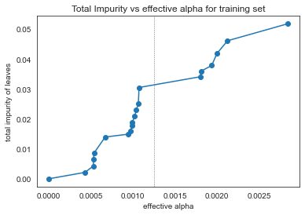

```python
pruning = m_tree.cost_complexity_pruning_path(X, y)

fig, ax = plt.subplots()
ax.plot(pruning.ccp_alphas[:-1], pruning.impurities[:-1], marker="o")
ax.set_xlabel("effective alpha")
ax.set_ylabel("total impurity of leaves")
ax.set_title("Total Impurity vs effective alpha for training set")
plt.axvline(x = 0.00125, linewidth = .5, color = "dimgray", linestyle = "--")
plt.show()
```

Avec le graphique ci-dessus, on propose de couper à $cp = 0.00125$ pour élaguer l'arbre complet.

```python
m_tree_elague = DecisionTreeClassifier(ccp_alpha=0.00125).fit(X, y)
```

```python
pandas.crosstab(m_tree_elague.predict(X), y)
```

| ozone row_0 | 0.0 | 1.0 |
| --- | --- | --- |
| 0.0 | 1787 | 27 |
| 1.0 | 4 | 30 |

```python
m_tree_elague.score(X, y)
```

```
0.9832251082251082
```

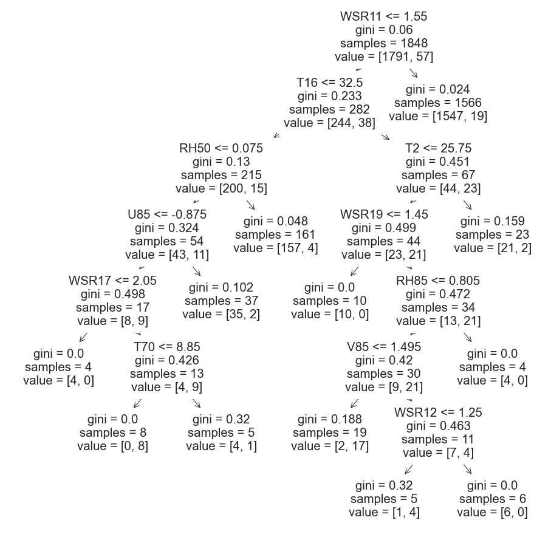

```python
plt.figure(figsize=(16, 16))
plot_tree(m_tree_elague, feature_names = X.columns)
plt.show()
```

### MLP

```python
r2 = []
auc_list = []

layers = ((), (10), (20), (50), (100), (10, 10), (20, 20), (50, 50), (100, 100),
          (10, 10, 10), (20, 20, 20), (50, 50, 50), (100, 100, 100))
for l in layers:
    m_mlp = MLPClassifier(hidden_layer_sizes = l, max_iter = 1000).fit(X, y)
    r2 = r2 + [m_mlp.score(X, y)]
    fpr, tpr, th = roc_curve(y, pandas.DataFrame(m_mlp.predict_proba(X))[1])
    auc_list = auc_list + [auc(fpr, tpr)]

df = pandas.DataFrame({
    "layers": layers,
    "r2": r2,
    "auc": auc_list
})
df
```

|  | layers | r2 | auc |
| --- | --- | --- | --- |
| 0 | () | 0.965909 | 0.812768 |
| 1 | 10 | 0.969156 | 0.561629 |
| 2 | 20 | 0.969156 | 0.490082 |
| 3 | 50 | 0.969156 | 0.836199 |
| 4 | 100 | 0.969156 | 0.710962 |
| 5 | (10, 10) | 0.969156 | 0.855995 |
| 6 | (20, 20) | 0.969697 | 0.758481 |
| 7 | (50, 50) | 0.969156 | 0.769177 |
| 8 | (100, 100) | 0.969156 | 0.819713 |
| 9 | (10, 10, 10) | 0.969156 | 0.771822 |
| 10 | (20, 20, 20) | 0.969156 | 0.799171 |
| 11 | (50, 50, 50) | 0.969156 | 0.698982 |
| 12 | (100, 100, 100) | 0.969156 | 0.500000 |

```python
m_mlp = MLPClassifier(hidden_layer_sizes = (10, 10), max_iter = 1000).fit(X, y)
```

```python
pandas.crosstab(m_mlp.predict(X), y)
```

| ozone row_0 | 0.0 | 1.0 |
| --- | --- | --- |
| 0.0 | 1677 | 39 |
| 1.0 | 114 | 18 |

```python
m_mlp.score(X, y)
```

```
0.9172077922077922
```

D'après les résultats ci-dessus, nous remarquons les éléments suivants :

- Le perceptron multi-couches obtenu fait énormément d'erreurs et n'est pas intéressant ici ;
- La régression logistique fonctionne assez bien, avec toutefois beaucoup de faux négatifs ;
- La méthode des $k$-plus proches voisins fonctionne un peu mieux, avec toujours beaucoup de faux négatifs ;
- L'arbre élagué permet de faire moins d'erreurs.

## 7- Comparaison des résultats

Nous comparons ici seulement les 3 méthodes intéressantes (régression logistique, $k$-plus proches voisins et arbre de décision).

```python
pandas.crosstab(m_log.predict(X), m_knn.predict(scale(X)))
```

| col_0 row_0 | 0.0 | 1.0 |
| --- | --- | --- |
| 0.0 | 1810 | 15 |
| 1.0 | 12 | 11 |

```python
pandas.crosstab(m_log.predict(X), m_tree_elague.predict(X))
```

| col_0 row_0 | 0.0 | 1.0 |
| --- | --- | --- |
| 0.0 | 1804 | 21 |
| 1.0 | 12 | 11 |

```python
pandas.crosstab(m_knn.predict(scale(X)), m_tree_elague.predict(X))
```

| col_0 row_0 | 0.0 | 1.0 |
| --- | --- | --- |
| 0.0 | 1807 | 15 |
| 1.0 | 9 | 17 |

## 8- Différence entre classes

```python
res = pandas.DataFrame({
    "ozone": y,
    "class": kmeans.labels_,
    "log": m_log.predict(X),
    "knn": m_knn.predict(scale(X)),
    "cart": m_tree_elague.predict(X)
})
res
```

|  | ozone | class | log | knn | cart |
| --- | --- | --- | --- | --- | --- |
| 0 | 0.0 | 2 | 0.0 | 0.0 | 0.0 |
| 1 | 0.0 | 1 | 0.0 | 0.0 | 0.0 |
| 2 | 0.0 | 1 | 0.0 | 0.0 | 0.0 |
| 3 | 0.0 | 1 | 0.0 | 0.0 | 0.0 |
| 6 | 0.0 | 1 | 0.0 | 0.0 | 0.0 |
| ... | ... | ... | ... | ... | ... |
| 2531 | 0.0 | 2 | 0.0 | 0.0 | 0.0 |
| 2532 | 0.0 | 2 | 0.0 | 0.0 | 0.0 |
| 2533 | 0.0 | 2 | 0.0 | 0.0 | 0.0 |
| 2534 | 0.0 | 0 | 0.0 | 0.0 | 0.0 |
| 2535 | 0.0 | 1 | 0.0 | 0.0 | 0.0 |

1848 rows × 5 columns

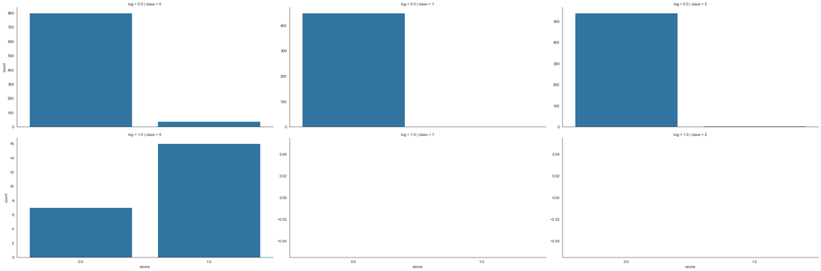

```python
g = seaborn.catplot(data = res, x = "ozone", col = "class", row = "log", kind = "count",
                    aspect = 2, sharey = False)
```

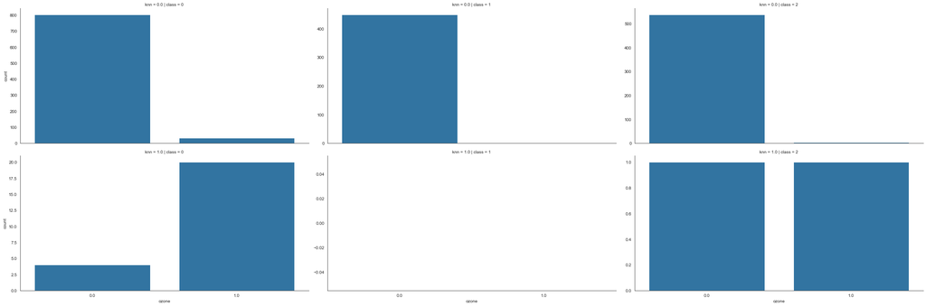

```python
g = seaborn.catplot(data = res, x = "ozone", col = "class", row = "knn", kind = "count",
                    aspect = 2, sharey = False)
```

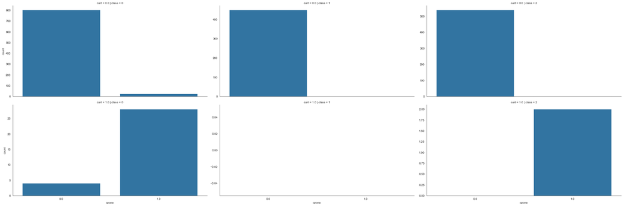

```python
g = seaborn.catplot(data = res, x = "ozone", col = "class", row = "cart", kind = "count",
                    aspect = 2, sharey = False)
```